# Oswego Foodborne Outbreak, 1940

Analysis of Gastrointestinal Illness Following a Church Supper

Author

Affiliation

[Kabinga Chanda](https://zm.linkedin.com/in/kabinga-chanda-7646b1211)

Core-Data

Abstract

A foodborne illness outbreak occurred among attendees of a church supper in Lycoming, Oswego County, New York, in April 1940. A retrospective cohort study was conducted among 75 of 80 attendees to collect demographic information, food consumption histories, and illness status. Gastrointestinal illness, including nausea, vomiting, and diarrhea, was reported by 46 participants (61%). Food-specific attack rates were calculated, and vanilla ice cream was associated with the highest attack rate (79.6% vs 14.3% among non-consumers). The epidemic curve indicated a point-source exposure with a median incubation period of 4 hours. Findings are consistent with Staphylococcus aureus food poisoning. This study highlights the importance of food safety practices in preventing outbreaks at community events.

Keywords

Epidemiology, Foodborne Illness, Oswego Outbreak

## Background

On 19 April 1940, a local health officer in Lycoming, Oswego County, New York, reported an outbreak of acute gastrointestinal illness. An epidemiologist-in-training was assigned to investigate. Preliminary information indicated that all reported cases had attended a church supper held on 18 April, while non-attendees were not affected. The supper took place in the church basement, where food contributed by congregation members was served over several hours. Illness was characterized by acute gastrointestinal symptoms, with rapid recovery and no reported fever.

## Methods

### Study Design

A retrospective cohort study was conducted among individuals who attended the church supper in Oswego. Data were collected through structured interviews to assess food exposures and illness outcomes following the event.

### Case Definition

A case was defined as any person who attended the church supper held in the basement of the village church in Lycoming, Oswego County, New York on 18 April 1940, and developed acute gastrointestinal symptoms, including nausea, vomiting, diarrhoea, or abdominal cramps, within 48 hours after the event.

### Data Collection

Information collected included demographic characteristics (age and sex), time of meal consumption, specific food items eaten, illness status, and time of symptom onset.

### Statistical Analysis

Descriptive statistics were used to summarise demographic characteristics of the study population. Food-specific attack rates, risk ratios, and corresponding 95% confidence intervals were calculated to assess associations between food exposures and illness. All analyses were conducted using R version 4.5.

## Results

Of the 80 individuals who attended the church supper, 75 were interviewed, and 46 (61%) reported gastrointestinal illness. Common symptoms included nausea, vomiting, diarrhoea, and abdominal pain, with illness duration of 24–30 hours. No cases reported fever. Onset of symptoms was acute, occurring within hours after the meal. Analysis of food-specific attack rates identified one food item with a substantially higher attack rate among cases compared to non-cases.

### Summary of Participant Characteristics and Demographics

**Outbreak of Gastrointestinal Illness in Oswego County, 1940**

| **Characteristic** | **Overall** N = 75<sup>1</sup> | **Ill** N = 46<sup>1</sup> | **Not Ill** N = 29<sup>1</sup> | **p-value**<sup>2</sup> |
| --- | --- | --- | --- | --- |
| Age (In Years) | 36 (16, 58) | 39 (17, 59) | 35 (14, 50) | 0.3 |
| Sex of the Participant |  |  |  | 0.15 |
| Female | 44 (59%) | 30 (65%) | 14 (48%) |  |
| Male | 31 (41%) | 16 (35%) | 15 (52%) |  |
| Incubation Period (In Hours) | 4.0 (3.0, 6.0) | 4.0 (3.0, 6.0) | NA (NA, NA) |  |

**Source:** Oswego An Outbreak of Gastrointestinal Illness Following a Church Supper (updated 2003): *https://www.cdc.gov/eis/casestudies/xoswego.401-303.student.pdf*  
<sup>1</sup> Median (Q1, Q3); n (%)  
<sup>2</sup> Wilcoxon rank sum test; Pearson’s Chi-squared test; NA

Of the 80 individuals who attended the church supper, 75 (94%) were interviewed. Among these, 46 (61%) reported gastrointestinal illness. The median age of participants was 36 years (IQR: 16–58); median age among ill participants was 39 years (IQR: 17–59) and among non-ill participants 35 years (IQR: 14–50) (p = 0.30). Females comprised 59% of participants, and males 41%, with no significant difference in illness status by sex (p = 0.15).

### Epidemic Curve

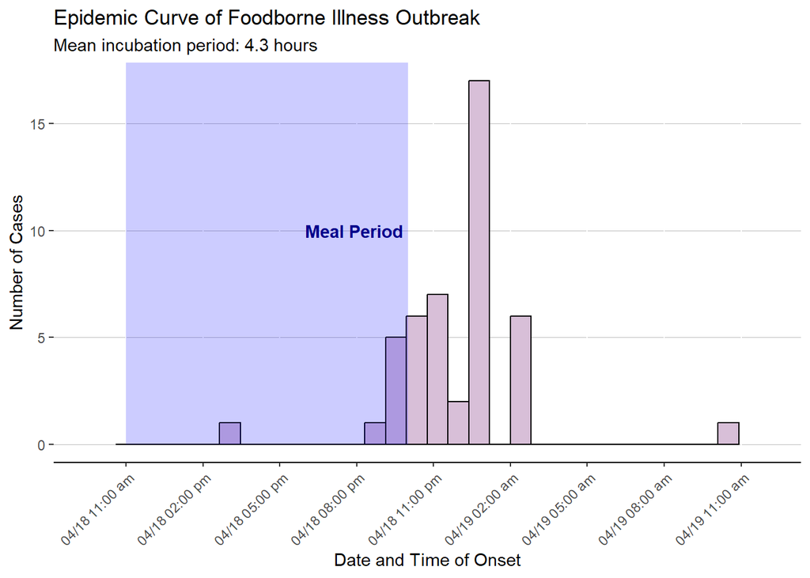

The epidemic curve showed that cases occurred within a short time period following the supper. The median incubation period among cases was 4.0 hours (IQR: 3.0–6.0).

### Food-Specific Attack Rates

**Food-specific Attack Rate Table**

Oswego County Outbreak Investigation, 1940

| **Food Item** | **Ate Food** **Ill** | **Ate Food** **Not Ill** | **Ate Food** **Total** | **Ate Food** Attack Rate (%) | **Did Not Eat Food** **Ill** | **Did Not Eat Food** **Not Ill** | **Did Not Eat Food** **Total** | **Did Not Eat Food** Attack Rate (%) | Attack Rate Ratio |  |
| --- | --- | --- | --- | --- | --- | --- | --- | --- | --- | --- |
| Vanilla Ice Cream | 43 | 11 | 54 | 79.6 | 3 | 18 | 21 | 14.3 |  | 5.6 |
| Cakes | 27 | 13 | 40 | 67.5 | 19 | 16 | 35 | 54.3 | 1.2 |  |
| Jello | 16 | 7 | 23 | 69.6 | 30 | 22 | 52 | 57.7 | 1.2 |  |
| Brown Bread | 18 | 9 | 27 | 66.7 | 28 | 20 | 48 | 58.3 | 1.1 |  |
| Fruit Salad | 4 | 2 | 6 | 66.7 | 42 | 27 | 69 | 60.9 | 1.1 |  |
| Baked Ham | 29 | 17 | 46 | 63.0 | 17 | 12 | 29 | 58.6 | 1.1 |  |
| Cabbage Salad | 18 | 10 | 28 | 64.3 | 28 | 19 | 47 | 59.6 | 1.1 |  |
| Coffee | 19 | 12 | 31 | 61.3 | 27 | 17 | 44 | 61.4 | 1.0 |  |
| Mashed Potato | 23 | 14 | 37 | 62.2 | 23 | 14 | 37 | 62.2 | 1.0 |  |
| Spinach | 26 | 17 | 43 | 60.5 | 20 | 12 | 32 | 62.5 | 1.0 |  |
| Rolls | 21 | 16 | 37 | 56.8 | 25 | 13 | 38 | 65.8 | 0.9 |  |
| Water | 13 | 11 | 24 | 54.2 | 33 | 18 | 51 | 64.7 | 0.8 |  |
| Milk | 2 | 2 | 4 | 50.0 | 44 | 27 | 71 | 62.0 | 0.8 |  |
| Chocolate Ice Cream | 25 | 22 | 47 | 53.2 | 20 | 7 | 27 | 74.1 | 0.7 |  |

AR = Attack Rate; Exposure = Ate the food (Y/N)

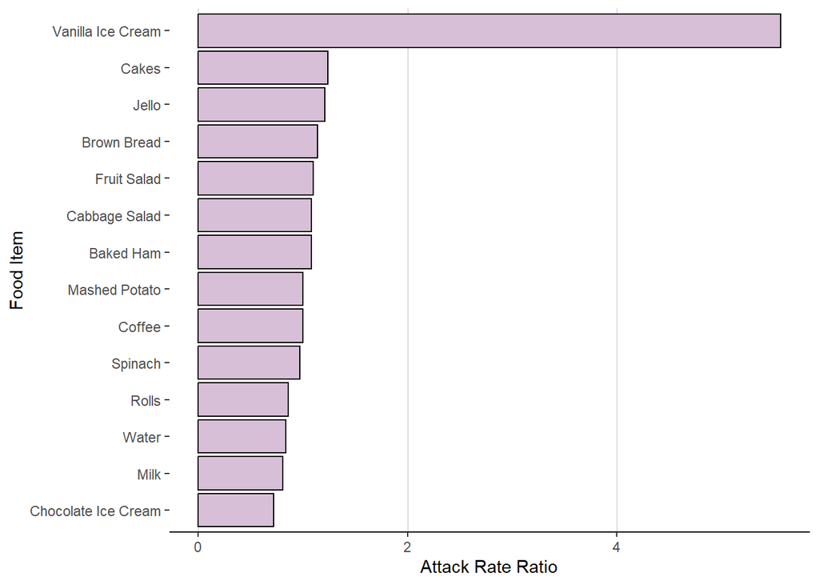

Attack rates for each food item were calculated. Vanilla ice cream had the highest attack rate among consumers (79.6%) compared with non-consumers (14.3%), resulting in an attack rate ratio of 5.6. Other food items had attack rates ranging from 50% to 69%, with attack rate ratios close to 1.0.

### Sex and Food-Specific Attack Rates

```r
### Stratied by Sex

# Step 1: Pivot foods to long format
att_rat_data_long <- data_clean |>
    pivot_longer(
        cols = baked.ham:fruit.salad,   # all food columns
        names_to = "food_item",
        values_to = "exposed"
    )




# Step 2: Calculate stratified attack rates by sex
att_rat_sex <- att_rat_data_long |>
    group_by(food_item, sex) |>
    summarise(
        Ill_exposed = sum(exposed == "Y" & ill == 1, na.rm = TRUE),
        NotIll_exposed = sum(exposed == "Y" & ill == 0, na.rm = TRUE),
        Ill_not_exposed = sum(exposed == "N" & ill == 1, na.rm = TRUE),
        NotIll_not_exposed = sum(exposed == "N" & ill == 0, na.rm = TRUE),
        Total_exposed = Ill_exposed + NotIll_exposed,
        Total_not_exposed = Ill_not_exposed + NotIll_not_exposed,
        AR_exposed = round(Ill_exposed / Total_exposed * 100, 1),
        AR_not_exposed = round(Ill_not_exposed / Total_not_exposed * 100, 1),
        Attack_Rate_Ratio = round(AR_exposed / AR_not_exposed, 2),
        .groups = "drop"
    ) |>
    arrange(food_item, sex)


# Create a named vector for nicer food names
food_names <- c(
    "baked.ham" = "Baked Ham",
    "brown.bread" = "Brown Bread",
    "cabbage.salad" = "Cabbage Salad",
    "cakes" = "Cakes",
    "chocolate.ice.cream" = "Chocolate Ice Cream",
    "coffee" = "Coffee",
    "fruit.salad" = "Fruit Salad",
    "jello" = "Jello",
    "mashed.potato" = "Mashed Potato",
    "milk" = "Milk",
    "rolls" = "Rolls",
    "spinach" = "Spinach",
    "vanilla.ice.cream" = "Vanilla Ice Cream",
    "water" = "Water"
)

# Apply nicer names to your table
att_rat_sex <- att_rat_sex |>
    mutate(food_item = food_names[food_item])


# Step 3: Create a publication-ready table with gt
att_rat_sex |>
    gt() |>
    tab_header(
        title = md("**Stratified Food-specific Attack Rates by Sex**"),
        subtitle = "Oswego-style Outbreak Analysis"
    ) |>
    tab_spanner(
        label = md("**Ate Food**"),
        columns = c(Ill_exposed, NotIll_exposed, Total_exposed, AR_exposed)
    ) |>
    tab_spanner(
        label = md("**Did Not Eat Food**"),
        columns = c(Ill_not_exposed, NotIll_not_exposed, Total_not_exposed, AR_not_exposed)
    ) |>
    cols_label(
        food_item = md("**Food Item**"),
        sex = "Sex",
        Ill_exposed = md("**Ill**"),
        NotIll_exposed =md("**Not Ill**"),
        Total_exposed = md("**Total**"),
        AR_exposed = md("**Attack<br> Rate (%)**"),
        Ill_not_exposed = md("**Ill**"),
        NotIll_not_exposed = md("**Not Ill**"),
        Total_not_exposed = md("**Total**"),
        AR_not_exposed = md("**Attack <br>Rate (%)**"),
        Attack_Rate_Ratio = md("**Attack <br>Rate Ratio**")
    ) |>
    fmt_number(
        columns = c(AR_exposed, AR_not_exposed, Attack_Rate_Ratio),
        decimals = 1
    ) |>
    tab_source_note(
        source_note = "AR = Attack Rate; Exposure = Ate the food (Y/N)"
    ) |>
    tab_options(
        table.border.top.style = "solid",
        table.border.bottom.style = "solid",
        column_labels.border.bottom.style = "solid",
        table_body.hlines.style = "none",
        table_body.vlines.style = "none"
    )
```

**Stratified Food-specific Attack Rates by Sex**

Oswego-style Outbreak Analysis

| **Food Item** | Sex | **Ate Food** **Ill** | **Ate Food** **Not Ill** | **Ate Food** **Total** | **Ate Food** Attack Rate (%) | **Did Not Eat Food** **Ill** | **Did Not Eat Food** **Not Ill** | **Did Not Eat Food** **Total** | **Did Not Eat Food** Attack Rate (%) | Attack Rate Ratio |  |
| --- | --- | --- | --- | --- | --- | --- | --- | --- | --- | --- | --- |
| Baked Ham | Female | 19 | 7 | 26 | 73.1 | 11 | 7 | 18 | 61.1 |  | 1.2 |
| Baked Ham | Male | 10 | 10 | 20 | 50.0 | 6 | 5 | 11 | 54.5 | 0.9 |  |
| Brown Bread | Female | 9 | 4 | 13 | 69.2 | 21 | 10 | 31 | 67.7 | 1.0 |  |
| Brown Bread | Male | 9 | 5 | 14 | 64.3 | 7 | 10 | 17 | 41.2 | 1.6 |  |
| Cabbage Salad | Female | 13 | 3 | 16 | 81.2 | 17 | 11 | 28 | 60.7 | 1.3 |  |
| Cabbage Salad | Male | 5 | 7 | 12 | 41.7 | 11 | 8 | 19 | 57.9 | 0.7 |  |
| Cakes | Female | 19 | 5 | 24 | 79.2 | 11 | 9 | 20 | 55.0 | 1.4 |  |
| Cakes | Male | 8 | 8 | 16 | 50.0 | 8 | 7 | 15 | 53.3 | 0.9 |  |
| Chocolate Ice Cream | Female | 19 | 11 | 30 | 63.3 | 11 | 3 | 14 | 78.6 | 0.8 |  |
| Chocolate Ice Cream | Male | 6 | 11 | 17 | 35.3 | 9 | 4 | 13 | 69.2 | 0.5 |  |
| Coffee | Female | 12 | 6 | 18 | 66.7 | 18 | 8 | 26 | 69.2 | 1.0 |  |
| Coffee | Male | 7 | 6 | 13 | 53.8 | 9 | 9 | 18 | 50.0 | 1.1 |  |
| Fruit Salad | Female | 1 | 1 | 2 | 50.0 | 29 | 13 | 42 | 69.0 | 0.7 |  |
| Fruit Salad | Male | 3 | 1 | 4 | 75.0 | 13 | 14 | 27 | 48.1 | 1.6 |  |
| Jello | Female | 11 | 3 | 14 | 78.6 | 19 | 11 | 30 | 63.3 | 1.2 |  |
| Jello | Male | 5 | 4 | 9 | 55.6 | 11 | 11 | 22 | 50.0 | 1.1 |  |
| Mashed Potato | Female | 13 | 7 | 20 | 65.0 | 17 | 7 | 24 | 70.8 | 0.9 |  |
| Mashed Potato | Male | 10 | 7 | 17 | 58.8 | 6 | 7 | 13 | 46.2 | 1.3 |  |
| Milk | Female | 1 | 0 | 1 | 100.0 | 29 | 14 | 43 | 67.4 | 1.5 |  |
| Milk | Male | 1 | 2 | 3 | 33.3 | 15 | 13 | 28 | 53.6 | 0.6 |  |
| Rolls | Female | 13 | 6 | 19 | 68.4 | 17 | 8 | 25 | 68.0 | 1.0 |  |
| Rolls | Male | 8 | 10 | 18 | 44.4 | 8 | 5 | 13 | 61.5 | 0.7 |  |
| Spinach | Female | 18 | 8 | 26 | 69.2 | 12 | 6 | 18 | 66.7 | 1.0 |  |
| Spinach | Male | 8 | 9 | 17 | 47.1 | 8 | 6 | 14 | 57.1 | 0.8 |  |
| Vanilla Ice Cream | Female | 27 | 4 | 31 | 87.1 | 3 | 10 | 13 | 23.1 | 3.8 |  |
| Vanilla Ice Cream | Male | 16 | 7 | 23 | 69.6 | 0 | 8 | 8 | 0.0 | Inf |  |
| Water | Female | 8 | 4 | 12 | 66.7 | 22 | 10 | 32 | 68.8 | 1.0 |  |
| Water | Male | 5 | 7 | 12 | 41.7 | 11 | 8 | 19 | 57.9 | 0.7 |  |

AR = Attack Rate; Exposure = Ate the food (Y/N)

## Discussion

This outbreak investigation identified a strong association between gastrointestinal illness and consumption of vanilla ice cream at a church supper in Oswego County. Individuals who consumed vanilla ice cream experienced a substantially higher attack rate than those who did not, and this pattern was consistent across sex strata. The epidemic curve suggested a point-source exposure, indicating a common vehicle of transmission.

The short incubation period, predominance of gastrointestinal symptoms without fever, and rapid recovery are consistent with foodborne intoxication, most likely caused by Staphylococcus aureus enterotoxin. Although laboratory confirmation was unavailable, the epidemiological findings and clinical presentation support this interpretation. Dairy-based foods are recognised vehicles for staphylococcal toxin transmission, particularly when temperature control is inadequate.

Strengths of the investigation included a clearly defined exposed population, high participation rate, and detailed food consumption data. Limitations included the retrospective study design, potential recall bias, absence of microbiological testing, and limited sample size, which restricted multivariable analysis.

These findings underscore the importance of proper food handling, temperature control, and hygiene during community events to prevent similar outbreaks.

## Conclusions

This investigation identified vanilla ice cream as the most likely vehicle of a foodborne outbreak among church supper attendees in Oswego County in 1940. The epidemiological and clinical features were consistent with staphylococcal food poisoning. These findings reinforce the importance of proper food handling and temperature control during community events.